# Unit 4 Notes

# Statistics for Business II | Summer 2026

## Linear Regression

- Linear regression is the statistical method for fitting a line to data where the relationship between two variables, $x$ and $y$, can be modeled by a straight line with some error
  - $\beta_0$ = y-intercept
  - $\beta_1$ = slope
  - $\epsilon$ = error term (a.k.a residual)

$$y = \beta_0 + \beta_1 x + \epsilon$$

- When we use $x$ to predict $y$, we usually call:
  - $x$ the explanatory, predictor or independent variable,
  - $y$ the response or dependent variable

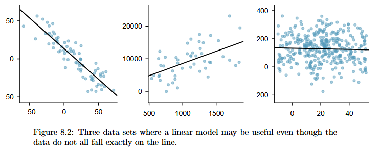

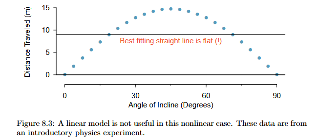

### Example 1: Opposums…?

```r
## read in data
x <- read.csv("data/opossum.csv")
head(x)
```

```
  site pop sex age head_l skull_w total_l tail_l
1    1 Vic   m   8   94.1    60.4    89.0   36.0
2    1 Vic   f   6   92.5    57.6    91.5   36.5
3    1 Vic   f   6   94.0    60.0    95.5   39.0
4    1 Vic   f   6   93.2    57.1    92.0   38.0
5    1 Vic   f   2   91.5    56.3    85.5   36.0
6    1 Vic   f   1   93.1    54.8    90.5   35.5
```

- I have no clue why the textbook uses this data, so I will make up an example for them
  - Imagine we are paleontologists and some old animal skulls.
  - Using data from modern animals, how big do we guess the animals’ whose skulls we found were?
- Side note: the data are from Australian brushtail possums which are much cuter than North American opossums
  - Note the spelling difference
  - In comparison, everything is cuter than NA opossums
- We know “skull size”; thus, it is our “x” variable
- We want to know “total size”; thus, it is our “y” variable

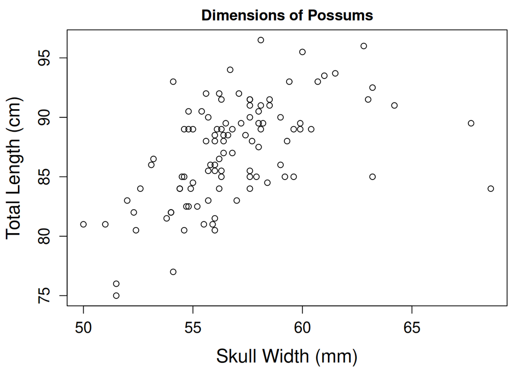

```r
## amount of white space to leave in a plot
par(mar = c(4.5, 4.5, 2, 1))

## scatter plot
plot(x$skull_w, x$total_l,
     xlab = "Skull Width (mm)",
     ylab = "Total Length (cm)",
     main = "Dimensions of Possums",
     cex.axis = 1.25,
     cex.lab = 1.5)
```

```r
## linear regression
lm1 <- lm(total_l ~ skull_w, data = x)
coefficients(lm1)
```

```
(Intercept)     skull_w
 45.6304994   0.7288203
```

```r
## range of outcomes
xs <- seq(min(x$skull_w)-5, max(x$skull_w)+5, 1)

## predicted values
b0 <- coefficients(lm1)[1]
b1 <- coefficients(lm1)[2]
y_hat <- b0 + b1 * xs

## combines Xs and predicted values
z <- data.frame(
  x = xs,
  y_hat = round(y_hat, 1)
)
head(z)
```

```
   x y_hat
1 45  78.4
2 46  79.2
3 47  79.9
4 48  80.6
5 49  81.3
6 50  82.1
```

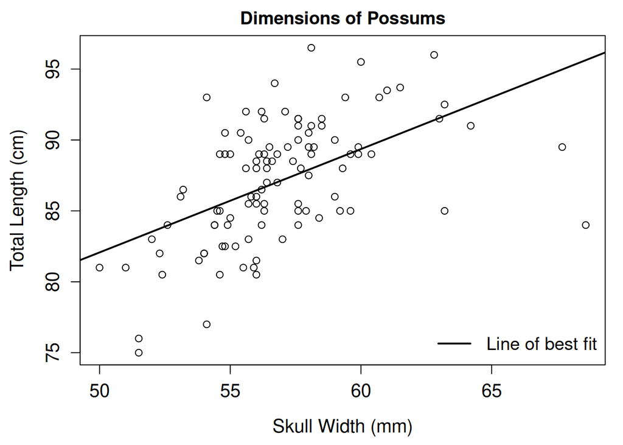

```r
## plot
par(mar = c(4.5, 4.5, 2, 1))
plot(x$skull_w, x$total_l,
     xlab = "Skull Width (mm)",
     ylab = "Total Length (cm)",
     main = "Dimensions of Possums",
     cex.lab = 1.25, cex.axis = 1.25)
lines(xs, y_hat, lwd = 2)
legend("bottomright",
       legend = "Line of best fit",
       lwd = 2, cex = 1.2, bty = 'n')
```

### Residuals

$$Data = Fit + Residual$$

- Residuals are the leftover variation after accounting fo the model fit

$$\epsilon_i = y_i - \hat{y_i}$$

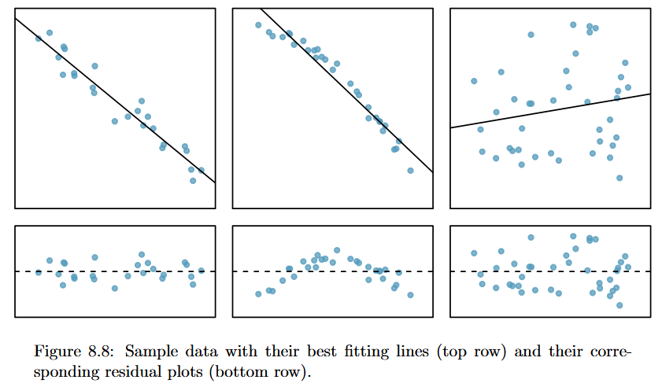

```r
## simplify data
p <- data.frame(
  x = x$skull_w,
  y = x$total_l,
  y_hat = predict(lm1)
)

## calculate residual
p$residual <- p$y - p$y_hat

## peak at data
head(p)
```

```
     x    y    y_hat  residual
1 60.4 89.0 89.65125 -0.651246
2 57.6 91.5 87.61055  3.889451
3 60.0 95.5 89.35972  6.140282
4 57.1 92.0 87.24614  4.753861
5 56.3 85.5 86.66308 -1.163083
6 54.8 90.5 85.56985  4.930148
```

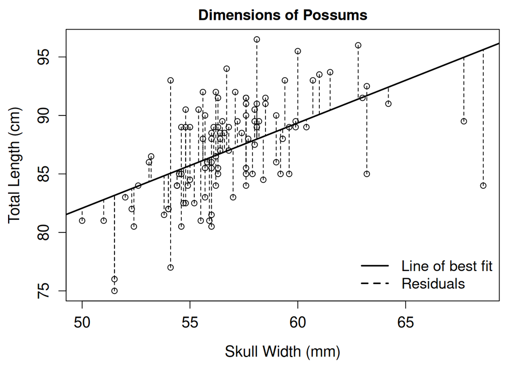

```r
## plot
par(mar = c(4.5, 4.5, 2, 1))
plot(x$skull_w, x$total_l,
     xlab = "Skull Width (mm)",
     ylab = "Total Length (cm)",
     main = "Dimensions of Possums",
     cex.lab = 1.25, cex.axis = 1.25)
lines(xs, y_hat, lwd = 2)
segments(p$x, p$y, p$x, p$y_hat, lty = 2)
legend("bottomright",
       legend = c("Line of best fit",
                  "Residuals"),
       lwd = 2, lty = c(1,2), cex = 1.2, bty = 'n')
```

### Correlation

$$R = \dfrac{1}{n-1} \sum_{i=1}^n \dfrac{x_i - \bar{x}}{s_x} \dfrac{y_i - \bar{y}}{s_y}$$

- Correlation describes the strength of the linear relationship between two variables
  - We denote the correlation by $R$
  - Always takes values between -1 and 1

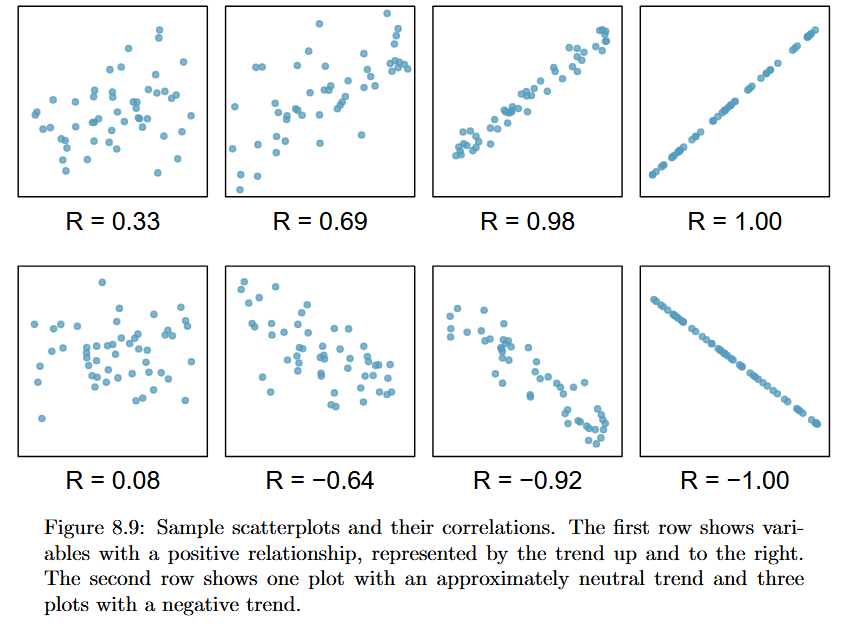

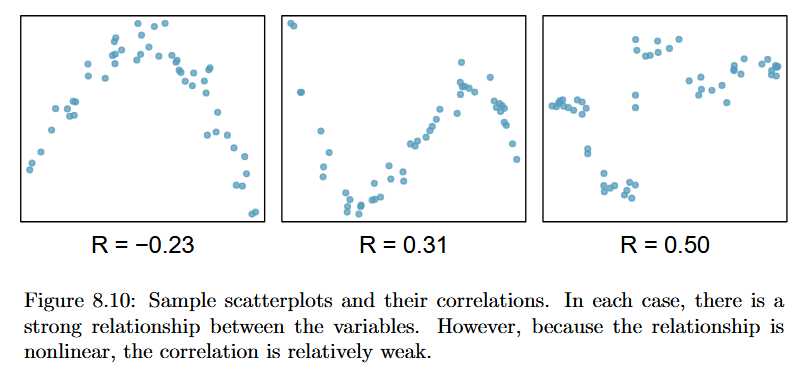

```r
## calculate by hand
zx <- (x$skull_w - mean(x$skull_w)) / sd(x$skull_w)
zy <- (x$total_l - mean(x$total_l)) / sd(x$total_l)
sum(zx * zy)/ (nrow(x) - 1)
```

```
[1] 0.5264127
```

```r
## calculate using the function in R
cor(x$skull_w, x$total_l)
```

```
[1] 0.5264127
```

### Conditions for the least squares line

- OLS: “Line of best fit”
- We begin by thinking about what we mean by “best”
  - Mathematically, we want a line that minimizes the magnitude of residuals
  - Most commonly, this is done by **minimizing the sum of the squared residuals**

$$min_{\hat{\beta_0}, \hat{\beta_1}} \sum_{i=1}^n e_i^2 = min_{\hat{\beta_0}, \hat{\beta_1}} \sum_{i=1}^n (y_i - \hat{\beta_0} - \hat{\beta_1}x_i)^2$$

- **Linearity**: The data should show a linear trend
- **Normal residuals**: Generally, the residuals must be nearly normal. When this condition is found to be unreasonable, it is usually because of outliers or concerns about influential points
- **Constant variability**: The variability of points around the least squares line remains roughly constant
- **Independent observations**: Be cautious about applying regression to time series data, which are sequential observations in time such as a stock price each day

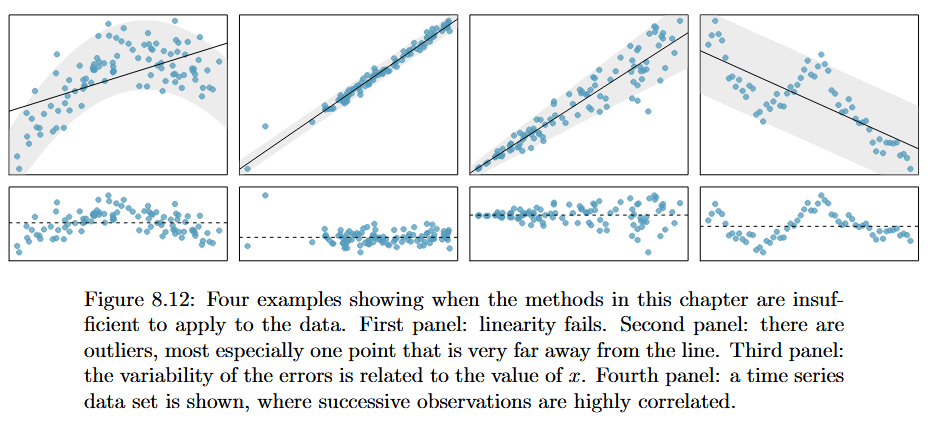

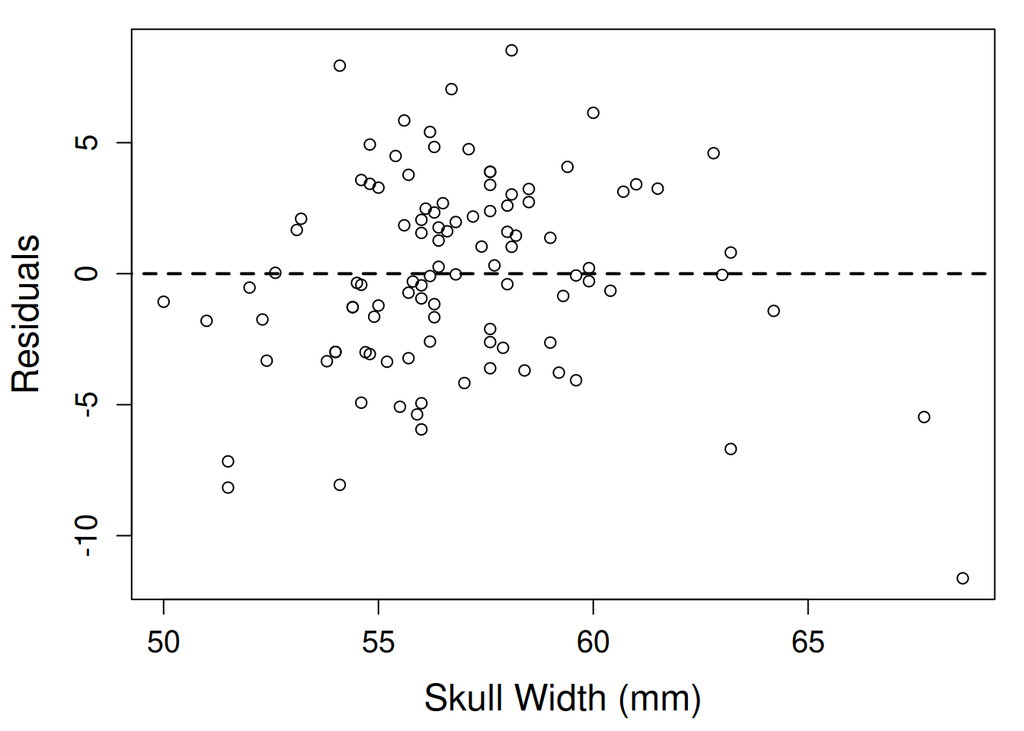

```r
## 1) Linearity. See the plot from the prior sections. It seems there is clear linear relationship.
## how do the residuals look though?

## scatter plot
par(mar = c(4.5, 4.5, 1, 1))
plot(p$x, p$residual,
     xlab = "Skull Width (mm)",
     ylab = "Residuals",
     cex.lab = 1.5, cex.axis = 1.25)

## is there a relationship between x and our residual?
## Add the regression line to the plot.
## The line is totally flat so there is no apparent relationship
lm2 <- lm(residual ~ x, data = p)
y_hat <- coefficients(lm2)[1] + coefficients(lm2)[2]*xs
lines(xs, y_hat, lty = 2, lwd = 2)
```

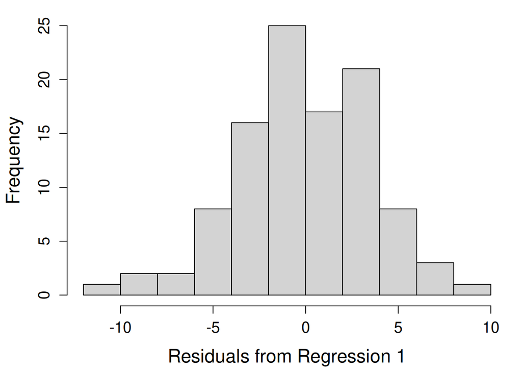

```r
## 2) Are the residuals "normal"?
## You betcha.

par(mar = c(4.5, 4.5, 1, 1))
hist(lm1$residuals,
     xlab = "Residuals from Regression 1",
     main = "",
     cex.lab = 1.5,
     cex.axis = 1.25)
```

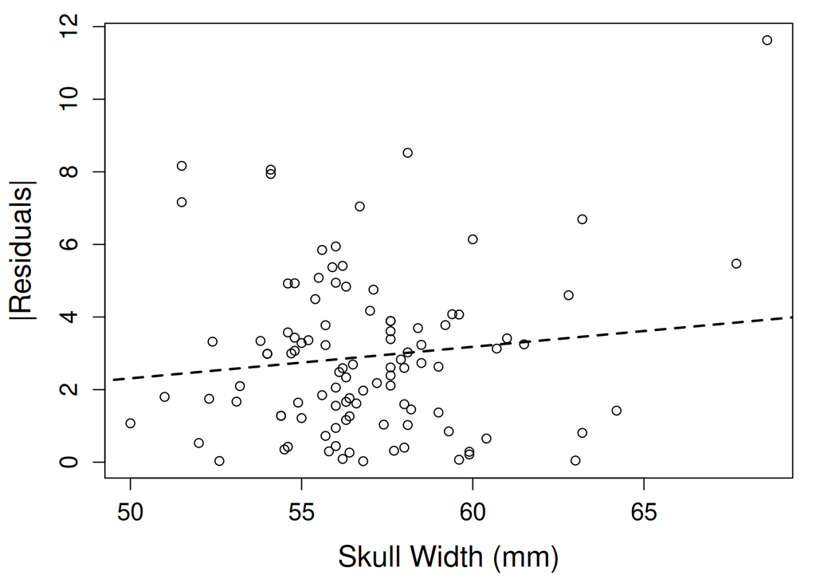

```r
## 3) What about the "magnitude" (or overall size of the residual)?
## In other words, do our predictions tend to get worse (larger residual value) as x increases?
## If so, not great news.

## scatter plot
## note that "abs" gives the absolute value
par(mar = c(4.5, 4.5, 1, 1))
plot(p$x, abs(p$residual),
     xlab = "Skull Width (mm)",
     ylab = "|Residuals|",
     cex.lab = 1.5, cex.axis = 1.25)
lm2 <- lm(abs(residual) ~ x, data = p)
y_hat <- coefficients(lm2)[1] + coefficients(lm2)[2]*xs
lines(xs, y_hat, lty = 2, lwd = 2)
```

### Example 2: Elmhurst College

```r
## read in data
x <- read.csv("data/elmhurst.csv")
head(x)
```

```
  family_income gift_aid price_paid
1        92.922    21.72      14.28
2         0.250    27.47       8.53
3        53.092    27.75      14.25
4        50.200    27.22       8.78
5       137.613    18.00      24.00
6        47.957    18.52      23.48
```

```r
## OLS
lm2 <- lm(gift_aid ~ family_income, x)
coefficients(lm2)
```

```
  (Intercept) family_income
  24.31932901   -0.04307165
```

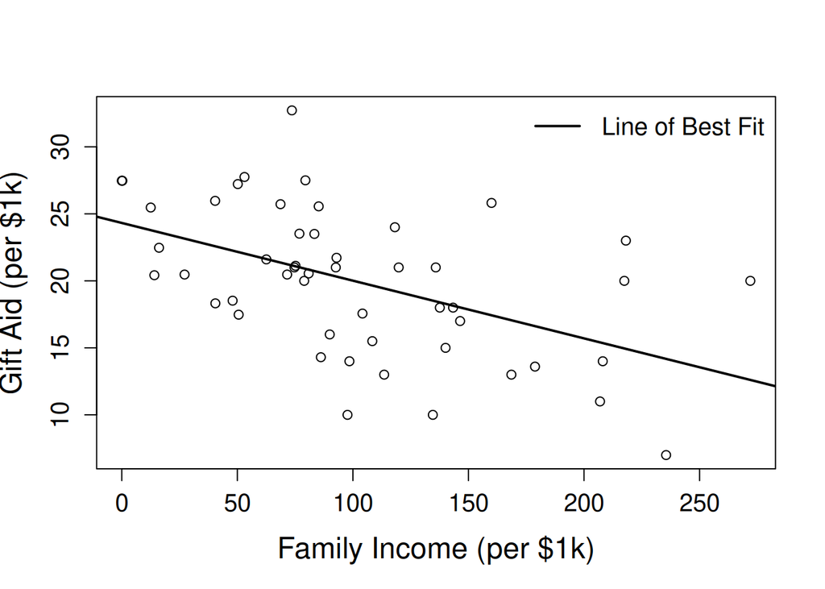

```r
## beta1 and beta0
b0 <- coefficients(lm2)[1]
b1 <- coefficients(lm2)[2]

# plot x and y
plot(x$family_income, x$gift_aid,
     xlab = "Family Income (per $1k)",
     ylab = "Gift Aid (per $1k)",
     cex.axis = 1.25, cex.lab = 1.5)
abline(lm2, lwd = 2)
legend("topright",
       legend = "Line of Best Fit",
       lwd = 2, cex = 1.25, bty = 'n')
```

```r
## simplify
y <- data.frame(
  x = x$family_income,
  y = x$gift_aid,
  y_hat = predict(lm2)
)

## calculate residuals
y$residuals <- y$y - y$y_hat

## peak at data
head(y)
```

```
        x     y    y_hat  residuals
1  92.922 21.72 20.31702  1.4029751
2   0.250 27.47 24.30856  3.1614389
3  53.092 27.75 22.03257  5.7174311
4  50.200 27.22 22.15713  5.0628679
5 137.613 18.00 18.39211 -0.3921097
6  47.957 18.52 22.25374 -3.7337418
```

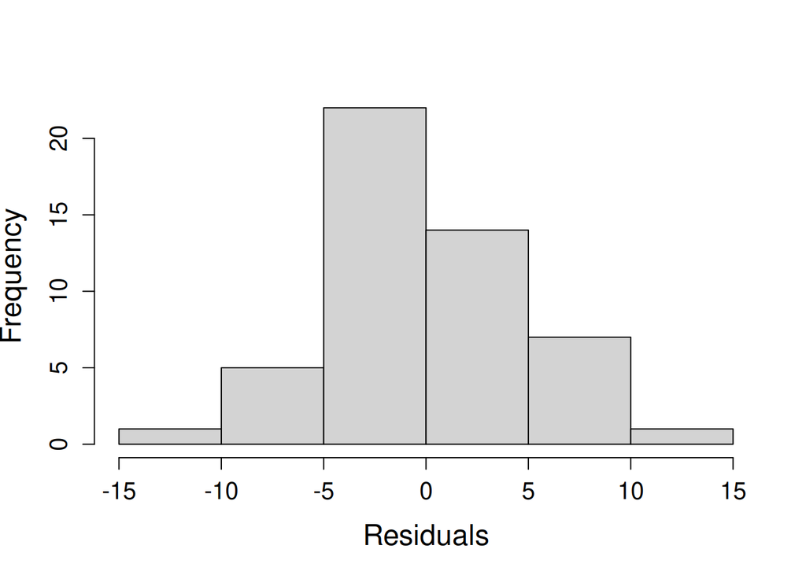

```r
## plot residuals distribution
hist(y$residuals, main = "",
     xlab = "Residuals",
     cex.axis = 1.25, cex.lab = 1.5)
```

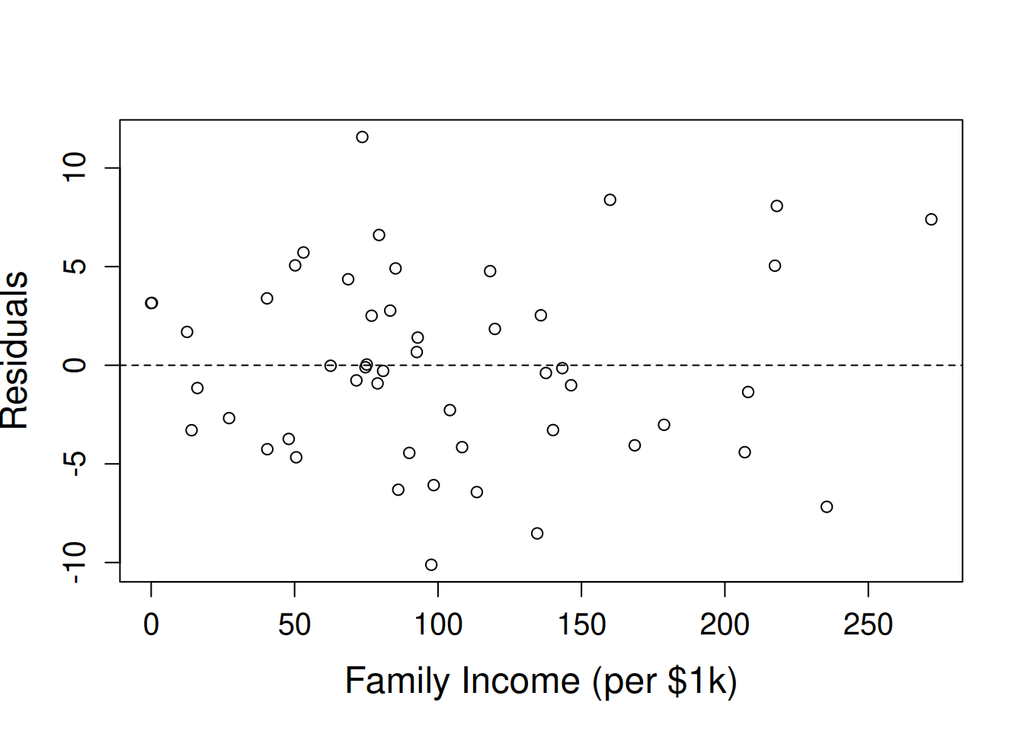

```r
## plot residuals and x
plot(y$x, y$residuals,
     xlab = "Family Income (per $1k)",
     ylab = "Residuals",
     cex.axis = 1.25, cex.lab = 1.5)
abline(h = 0, lty = 2)
```

### Slope

$$b_1 = \dfrac{s_y}{s_x} R$$

```r
## correlation
r <- cor(x$gift_aid, x$family_income)
r
```

```
[1] -0.4985561
```

```r
# beta 1, by hand
sd_y <- sd(x$gift_aid)
sd_x <- sd(x$family_income)
sd_y / sd_x * r
```

```
[1] -0.04307165
```

```r
## beta 1, by R
coefficients(lm2)[2]
```

```
family_income
  -0.04307165
```

### Intercept

$$y - y_0 = m \times (x - x_0)$$

- You might recall the point-slope form of a line from math class, which we can use to find the model fit, including the estimate of $\beta_0$

$$y - \bar{y} = \beta_1 \times (x - \bar{x})$$

- To find the y-intercept, set $x = 0$

$$b_0 = \bar{y} - \beta_1 \bar{x}$$

```r
## beta0, by hand
mean_y <- mean(x$gift_aid)
mean_x <- mean(x$family_income)
(mean_y - b1*mean_x)
```

```
family_income
     24.31933
```

```r
# beta0, by R
coefficients(lm2)[1]
```

```
(Intercept)
   24.31933
```

### Extrapolation

- Applying a model estimate to values outside of the realm of the original data is called **extrapolation**.
  - If we extrapolate, we are making an unreliable bet that the approximate linear relationship will be valid in places where it has not been analyzed.

[figure not shown]

### Strength of a fit: R-squared

- We evaluated the strength of the linear relationship between two variables earlier using the correlation, $R$.
  - However, it is more common to explain the strength of a linear fit using $R^2$
  - If provided with a linear model, we might like to describe how closely the data cluster around the linear fit.

$$R^2 = \dfrac{s_y^2 - s_\epsilon^2}{s_y^2}$$

```r
## R2 by hand
sy2 <- sd(y$y)^2
se2 <- sd(y$residuals)^2
(sy2 - se2) / sy2
```

```
[1] 0.2485582
```

```r
## R2 by R
summary(lm2)$r.squared
```

```
[1] 0.2485582
```

- About 25% of the variation in gift aid can be explained by differences in family income.

### Example 3: Mario Kart

```r
## read in data
x <- read.csv("data/mariokart.csv")

## clean up data
y <- data.frame(
  new = ifelse(x$cond == "new", 1, 0),
  price = x$total_pr
)
summary(y)
```

```
      new             price
 Min.   :0.0000   Min.   : 28.98
 1st Qu.:0.0000   1st Qu.: 41.17
 Median :0.0000   Median : 46.50
 Mean   :0.4126   Mean   : 49.88
 3rd Qu.:1.0000   3rd Qu.: 53.99
 Max.   :1.0000   Max.   :326.51
```

```r
## standardize outcome
z <- (y$price - mean(y$price)) / sd(y$price)

## remove outliers
y <- y[z <= 2.576,]

## run regression
lm3 <- lm(price ~ new, y)
coefficients(lm3)
```

```
(Intercept)         new
   42.87110    10.89958
```

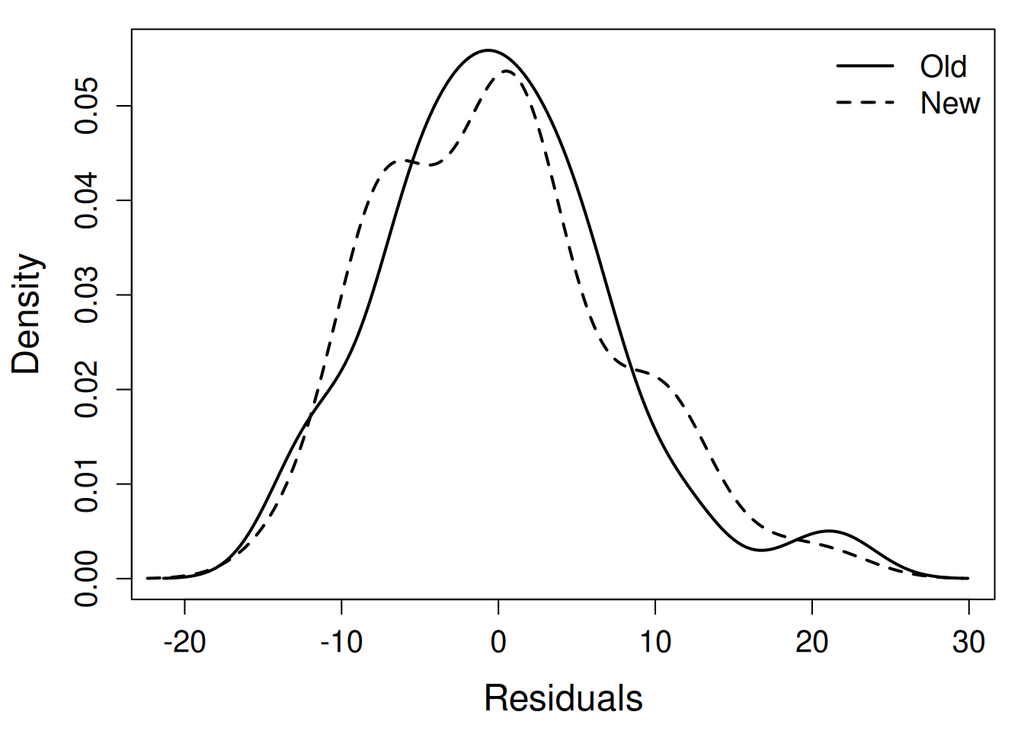

```r
## fitted values
y$y_hat <- predict(lm3, y)
y$residuals <- y$price - y$y_hat

## density of residuals and x
d_old <- density(y$residuals[y$new == 0])
d_new <- density(y$residuals[y$new == 1])

## plot residuals and x
par(mar = c(4.5, 4.5, 1, 1))
plot(d_old$x, d_old$y,
     type = "l", lwd = 2,
     xlab = "Residuals", ylab = "Density",
     cex.lab = 1.5, cex.axis = 1.25)
lines(d_new$x, d_new$y, lty = 2, lwd = 2)
legend("topright",
       legend = c("Old", "New"),
       lwd = 2, lty = c(1,2),
       cex = 1.25, bty = "n")
```

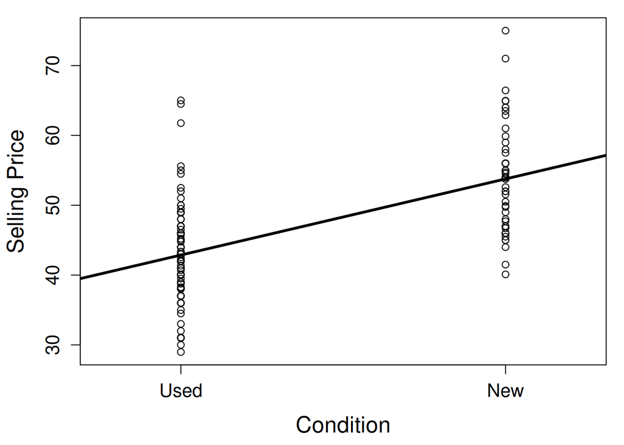

```r
## plot x and y
plot(y$new, y$price,
     xlim = c(-0.25, 1.25),
     xlab = "Condition", ylab = "Selling Price",
     xaxt = 'n', cex.axis = 1.25, cex.lab = 1.5)
axis(1, at = c(0,1), labels = c("Used", "New"), cex.axis = 1.25)
abline(lm3, lwd = 3)
```

```r
## summarize
summary(lm3)
```

```
Call:
lm(formula = price ~ new, data = y)

Residuals:
     Min       1Q   Median       3Q      Max
-13.8911  -5.8311   0.1289   4.1289  22.1489

Coefficients:
            Estimate Std. Error t value Pr(>|t|)
(Intercept)   42.871      0.814  52.668  < 2e-16 ***
new           10.900      1.258   8.662 1.06e-14 ***
---
Signif. codes:  0 '***' 0.001 '**' 0.01 '*' 0.05 '.' 0.1 ' ' 1

Residual standard error: 7.371 on 139 degrees of freedom
Multiple R-squared:  0.3506,    Adjusted R-squared:  0.3459
F-statistic: 75.03 on 1 and 139 DF,  p-value: 1.056e-14
```

- The estimated intercept is the value of the response variable for the first category.
  - The intercept is the estimated price when $new$ takes value 0, i.e. when the game is in used condition.
  - That is, the average selling price of a used version of the game is $42.87.
- The estimated slope is the average change in the response variable between the two categories.
  - The slope indicates that, on average, new games sell for about $10.90 more than used games.

### Example 4: Midterm elections

- **Context:** U.S. House elections occur every two years; those held **midway through a presidential term** are called **midterms**.
- **Theory:** When **unemployment is high**, the **President’s party performs worse** in midterms.
- **Approach:** Use **historical data (1898–2018)** (excluding **Great Depression** years) to test whether **unemployment predicts midterm losses**.

[figure not shown]

- $H_0: \beta_1 = 0$
- $H_A: \beta_1 \neq 0$

```r
## read in data
x <- read.csv("data/midterms_house.csv")
head(x)
```

```
  year               potus      party unemp house_change
1 1899    William McKinley Republican 11.62    -9.223301
2 1903  Theodore Roosevelt Republican  4.30    -4.275907
3 1907  Theodore Roosevelt Republican  3.29   -12.291499
4 1911 William Howard Taft Republican  5.86   -26.590640
5 1915      Woodrow Wilson   Democrat  6.63   -20.962199
6 1919      Woodrow Wilson   Democrat  3.38   -10.280374
```

```r
# standardize outcome
z <- (x$unemp - mean(x$unemp)) / sd(x$unemp)

## remove outliers
x <- x[z <= 2.576,]

## run regression
lm4 <- lm(house_change ~ unemp, x)
coefficients(lm4)
```

```
(Intercept)       unemp
 -7.3644063  -0.8897261
```

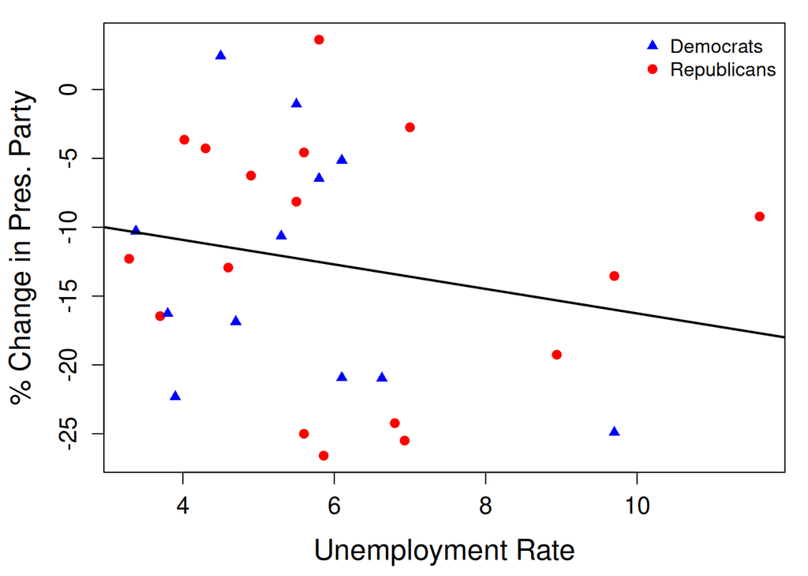

```r
## plot
par(mar = c(4.5, 4.5, 1, 1))
plot(x$unemp[x$party == "Republican"],
     x$house_change[x$party == "Republican"],
     xlab = "Unemployment Rate", ylab = "% Change in Pres. Party",
     cex.lab = 1.5, cex.axis = 1.25, pch = 19, col = "red")
points(x$unemp[x$party == "Democrat"],
       x$house_change[x$party == "Democrat"],
       pch = 17, col = "blue")
abline(lm4, lwd = 2)
legend("topright",
       legend = c("Democrats",
                  "Republicans"),
       pch = c(17, 19), col = c("blue", "red"),
       bty = "n")
```

- There seems to be a modest, negative relationship between the unemployment rate and how many seats the president’s party loses in midterm elections.
  - Is this a **statisically meaningful** relationship?
  - Regression analysis can answer this quickly and easily. To see how, lets simulate.

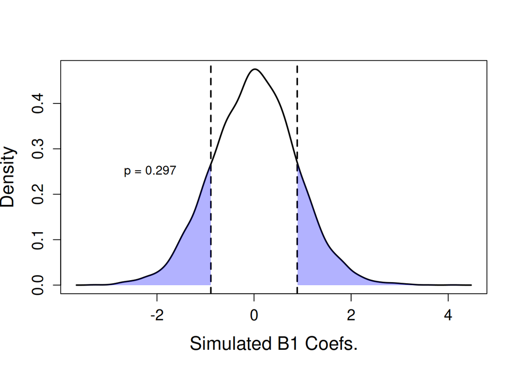

```r
## standard deviations of the x and y variables
sd_x <- sd(x$unemp)
sd_y <- sd(x$house_change)

## set up loop
n <- nrow(x)
z <- list()

## loop 10k times
for(i in 1:10000){

  set.seed(i)

  ## generate data
  ### note that we assume that there is no difference in means (null)
  y <- data.frame(
    x = rnorm(n, mean = 0, sd = sd_x),
    y = rnorm(n, mean = 0, sd = sd_y)
  )

  ## store b1
  z[[length(z)+1]] <- coefficients(lm(y ~ x, y))[2]

}

## unlist
z <- unlist(z)

## density of generated b1
dz <- density(z)

## plot generated b1s
plot(dz$x, dz$y, type = "l", lwd = 2,
     ylab = "Density", xlab = "Simulated B1 Coefs.",
     cex.axis = 1.25, cex.lab = 1.5)

## real b1
b1 <- as.numeric(coefficients(lm4)[2])

## plot real b1
abline(v = c(-b1, b1), lty = 2, lwd = 2)

## RHS
x_fill <- dz$x[dz$x <= b1]
y_fill <- dz$y[dz$x <= b1]
polygon(c(min(x_fill), x_fill, b1),
        c(0, y_fill, 0),
        col = rgb(0, 0, 1, 0.3), border = NA)

## LHS
x_fill <- dz$x[dz$x >= -b1]
y_fill <- dz$y[dz$x >= -b1]
polygon(c(min(x_fill), x_fill, -b1),
        c(0, y_fill, 0),
        col = rgb(0, 0, 1, 0.3), border = NA)

## p-value on figure
text(b1-1.25, 0.25,
     paste("p =", round(mean(ifelse(b1 >= z, 1, 0))*2, 3)))
```

```r
## p-value from simulation
mean(ifelse(b1 >= z, 1, 0))*2
```

```
[1] 0.2972
```

```r
## p-value from R (for b1)
summary(lm4)
```

```
Call:
lm(formula = house_change ~ unemp, data = x)

Residuals:
     Min       1Q   Median       3Q      Max
-14.0124  -7.6989   0.0913   7.2974  16.1447

Coefficients:
            Estimate Std. Error t value Pr(>|t|)
(Intercept)  -7.3644     5.1553  -1.429    0.165
unemp        -0.8897     0.8350  -1.066    0.296

Residual standard error: 8.913 on 27 degrees of freedom
Multiple R-squared:  0.04035,   Adjusted R-squared:  0.004812
F-statistic: 1.135 on 1 and 27 DF,  p-value: 0.2961
```

- If the null hypothesis is true (i.e. there is no relationship between the unemployment rate and midterm election outcomes), what percentage of the time would we expect to find an “effect” so large?
  - About 30% of the time
  - This is not enough evidence to reject the null

## Multiple Regression

- **Multiple regression** extends simple two-variable regression to situations with one response variable and multiple predictors (denoted $x_1$, $x_2$, $x_3$, …).
  - It is motivated by cases where several factors may simultaneously influence an outcome
- A multiple regression model is a linear model with multiple predictors In general, we write the model as… where there are $k$ predictors

$$\hat{y} = \beta_0 + \beta_1 x_1 + \beta_2 x_2 + \dots + \beta_k x_k$$

### Example 1: Bankruptcy

- We will consider data on loans from the peer-to-peer lender, Lending Club.
- The dataset includes both **loan characteristics** and **borrower information**.
  - Our goal is to understand the factors that influence the **interest rate assigned to each loan**.
- Holding all other characteristics constant:
  - Does it matter **how much debt someone already has**?
  - Does it matter **whether their income has been verified**?

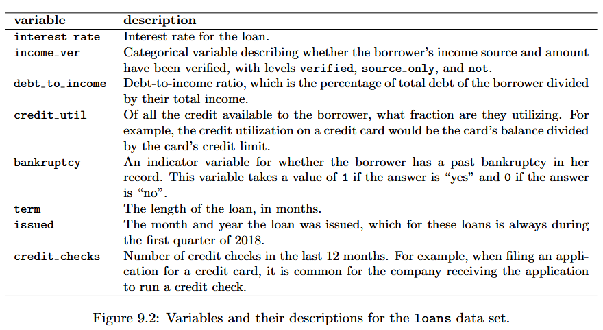

```r
## read in data
x <- read.csv("data/loans_full_schema.csv")
dim(x)
```

```
[1] 10000    55
```

```r
# simplify
y <- data.frame(
  interest_rate = x$interest_rate,
  income_ver = x$verified_income,
  debt_to_income = x$debt_to_income,
  credit_util = x$total_credit_utilized / x$total_credit_limit,
  bankruptcy = ifelse(x$public_record_bankrupt > 0, 1, 0),
  term = x$term,
  issued = x$issue_month,
  credit_checks = x$inquiries_last_12m
)

## peak at data
head(y)
```

```
  interest_rate      income_ver debt_to_income credit_util bankruptcy term
1         14.07        Verified          18.01  0.54759517          0   60
2         12.61    Not Verified           5.04  0.15003472          1   36
3         17.09 Source Verified          21.15  0.66134832          0   36
4          6.72    Not Verified          10.16  0.19673228          0   36
5         14.07        Verified          57.96  0.75490772          0   36
6          6.72    Not Verified           6.46  0.09258907          0   36
    issued credit_checks
1 Mar-2018             6
2 Feb-2018             1
3 Feb-2018             4
4 Jan-2018             0
5 Mar-2018             7
6 Jan-2018             6
```

```r
# run regression
lm1 <- lm(interest_rate ~ bankruptcy, data = y)
summary(lm1)
```

```
Call:
lm(formula = interest_rate ~ bankruptcy, data = y)

Residuals:
    Min      1Q  Median      3Q     Max
-7.7648 -3.6448 -0.4548  2.7120 18.6020

Coefficients:
            Estimate Std. Error t value Pr(>|t|)
(Intercept)  12.3380     0.0533 231.490  < 2e-16 ***
bankruptcy    0.7368     0.1529   4.819 1.47e-06 ***
---
Signif. codes:  0 '***' 0.001 '**' 0.01 '*' 0.05 '.' 0.1 ' ' 1

Residual standard error: 4.996 on 9998 degrees of freedom
Multiple R-squared:  0.002317,  Adjusted R-squared:  0.002217
F-statistic: 23.22 on 1 and 9998 DF,  p-value: 1.467e-06
```

- Note the regression coefficient here
  - Since $\beta_1$ is binary, we interpret this as meaning that individuals who have filed for bankruptcy before pay, on average, 0.74 **percentage points** more on their loan
  - Where does this number come from?

```r
## aggregate data
z <- aggregate(interest_rate ~ bankruptcy, y,
               function(x) c(mean = mean(x),
                             sd = sd(x),
                             n = length(x)))
z <- as.data.frame(do.call(cbind, z))

## add C.I.s
z$min <- z$mean - 1.96 * z$sd / sqrt(z$n)
z$max <- z$mean + 1.96 * z$sd / sqrt(z$n)
z
```

```
  bankruptcy     mean       sd    n      min      max
1          0 12.33800 5.018019 8785 12.23307 12.44294
2          1 13.07479 4.829929 1215 12.80320 13.34638
```

```r
# b1
z$mean[2] - z$mean[1]
```

```
[1] 0.7367856
```

- How do we know that this percentage point difference is statistically signficant?

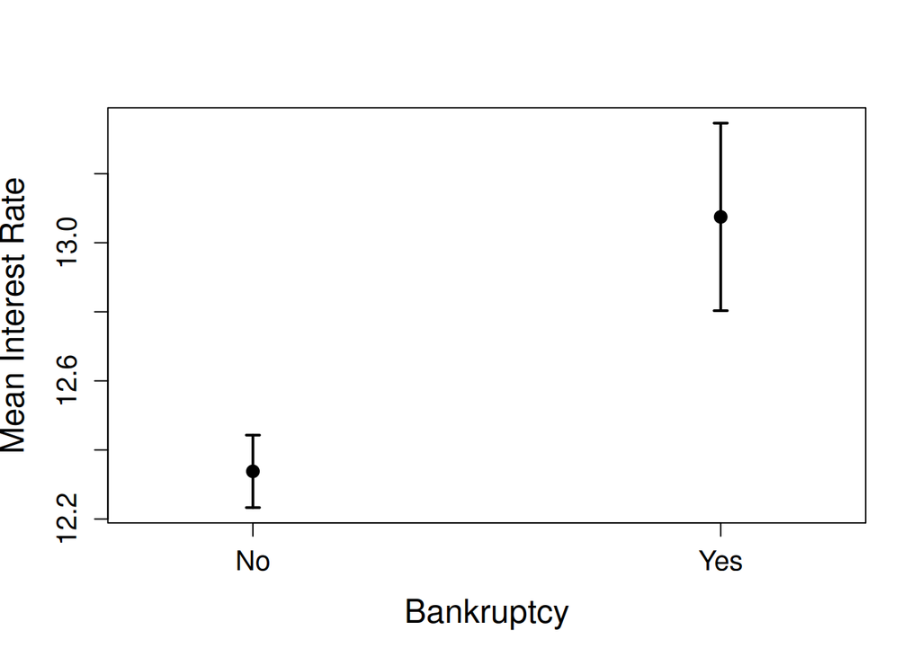

```r
## plot
plot(z$bankruptcy, z$mean,
     ylim = c(min(z$min), max(z$max)),
     xlim = c(-0.25, 1.25),
     xaxt = "n", pch = 19, cex = 1.25,
     ylab = "Mean Interest Rate", xlab = "Bankruptcy",
     cex.lab = 1.5, cex.axis = 1.25)
axis(1, at = c(0, 1), labels = c("No", "Yes"), cex.axis = 1.25)
arrows(z$bankruptcy, z$min, z$bankruptcy, z$max,
       angle = 90, code = 3, length = 0.05, lwd = 2)
```

- Now let’s analyze a new variable: Income Verification
  - Note this is categorical, but not binary

```r
## all possible values it takes
unique(y$income_ver)
```

```
[1] "Verified"        "Not Verified"    "Source Verified"
```

```r
## run regression
lm2 <- lm(interest_rate ~ income_ver, data = y)
summary(lm2)
```

```
Call:
lm(formula = interest_rate ~ income_ver, data = y)

Residuals:
    Min      1Q  Median      3Q     Max
-9.0437 -3.7495 -0.6795  2.5345 19.6905

Coefficients:
                          Estimate Std. Error t value Pr(>|t|)
(Intercept)               11.09946    0.08091  137.18   <2e-16 ***
income_verSource Verified  1.41602    0.11074   12.79   <2e-16 ***
income_verVerified         3.25429    0.12970   25.09   <2e-16 ***
---
Signif. codes:  0 '***' 0.001 '**' 0.01 '*' 0.05 '.' 0.1 ' ' 1

Residual standard error: 4.851 on 9997 degrees of freedom
Multiple R-squared:  0.05945,   Adjusted R-squared:  0.05926
F-statistic: 315.9 on 2 and 9997 DF,  p-value: < 2.2e-16
```

- How do we interpret this?
  - Relative to having one’s income **not verified**, what is the average difference in interest rates paid?
  - Counter intuitively, ‘no verification’ borrowers pay less in interest. Why?

```r
## aggregate
z <- aggregate(interest_rate ~ income_ver, y,
               function(x) c(mean = mean(x),
                             sd = sd(x),
                             n = length(x)))
z <- as.data.frame(do.call(cbind, z))
z[,2:4] <- apply(z[,2:4], 2, as.numeric)
z$min <- z$mean - 1.96 * z$sd / sqrt(z$n)
z$max <- z$mean + 1.96 * z$sd / sqrt(z$n)
z
```

```
       income_ver     mean       sd    n      min      max
1    Not Verified 11.09946 4.569159 3594 10.95007 11.24884
2 Source Verified 12.51548 4.735268 4116 12.37081 12.66014
3        Verified 14.35375 5.447896 2290 14.13061 14.57688
```

```r
## b1
z$mean[2] - z$mean[1]
```

```
[1] 1.416021
```

```r
## b2
z$mean[3] - z$mean[1]
```

```
[1] 3.254289
```

- This regression output provides multiple rows for the **income verification** variable.
  - Each row represents the relative difference for each level of `income_ver`.
- However, one level is missing: *Not Verified*.
  - The missing level is called the **reference group**, representing the default category that all other levels are measured against.
- The higher interest rate for borrowers who have verified their income is surprising.
  - Intuitively, we might expect verified income to make a loan **less risky**.
- However, the situation may be more complex and could involve **confounding variables** that we haven’t accounted for.
  - For example, perhaps lenders require borrowers with **poor credit** to verify their income. In that case, income verification could signal *concern about repayment* rather than *reassurance*. This would make the borrower appear higher risk, leading to a higher interest rate.
- **Omitted variable bias** occurs when a model leaves out relevant variables, leading to **biased or misleading estimates** of the included predictors.
  - The effects of the missing variables are incorrectly attributed to those remaining in the model, distorting interpretation.
- Now, let’s add as many variables as possible.

```r
## run regression
lm3 <- lm(interest_rate ~ income_ver + debt_to_income + credit_util + bankruptcy + term + issued + credit_checks, data = y)

## summarize
summary(lm3)
```

```
Call:
lm(formula = interest_rate ~ income_ver + debt_to_income + credit_util +
    bankruptcy + term + issued + credit_checks, data = y)

Residuals:
     Min       1Q   Median       3Q      Max
-12.1219  -3.0984  -0.7247   2.3318  18.8160

Coefficients:
                           Estimate Std. Error t value Pr(>|t|)
(Intercept)                1.893839   0.210245   9.008  < 2e-16 ***
income_verSource Verified  0.997468   0.099187  10.056  < 2e-16 ***
income_verVerified         2.563168   0.117184  21.873  < 2e-16 ***
debt_to_income             0.021832   0.002937   7.434 1.14e-13 ***
credit_util                4.896988   0.161887  30.249  < 2e-16 ***
bankruptcy                 0.391105   0.132286   2.957  0.00312 **
term                       0.153388   0.003944  38.889  < 2e-16 ***
issuedJan-2018             0.045510   0.108034   0.421  0.67358
issuedMar-2018            -0.041624   0.106545  -0.391  0.69605
credit_checks              0.228321   0.018242  12.516  < 2e-16 ***
---
Signif. codes:  0 '***' 0.001 '**' 0.01 '*' 0.05 '.' 0.1 ' ' 1

Residual standard error: 4.3 on 9964 degrees of freedom
  (26 observations deleted due to missingness)
Multiple R-squared:  0.2604,    Adjusted R-squared:  0.2597
F-statistic: 389.7 on 9 and 9964 DF,  p-value: < 2.2e-16
```

- We estimate the parameters $\beta_0, \beta_1, \beta_2...,\beta_9$ that minimize the sum of the squared residuals:

$$SSE = e_1^2 + e_2^2 + ... + e_{10,000}^2 = \sum_{i=1}^{10,000} e_i^2 = \sum_{i=1}^{10,000} (y_i - \hat{y_i})^2$$

### Collinearity

- Including multiple predictors helps reduce or eliminate **omitted variable bias**, but another challenge can arise: **correlation among predictors**.
  - When two or more predictors are correlated, we say they are **collinear**.
  - This **collinearity** makes it difficult to disentangle each variable’s individual contribution to the response, and can complicate model estimation and interpretation.

```r
## correlation matrix
round(cor(y[complete.cases(y),-c(1, 2, 7)]), 2)
```

```
               debt_to_income credit_util bankruptcy  term credit_checks
debt_to_income           1.00        0.13       0.01  0.05          0.03
credit_util              0.13        1.00       0.04 -0.04         -0.02
bankruptcy               0.01        0.04       1.00  0.00          0.08
term                     0.05       -0.04       0.00  1.00          0.03
credit_checks            0.03       -0.02       0.08  0.03          1.00
```

- As a rule of thumb, avoid including variables whose pairwise correlation exceeds $0.8$ – here, everything sits comfortably below that threshold
  - When two predictors are highly correlated, the model can’t separate their individual contributions. Standard errors inflate, and both variables can appear insignificant even though the pair is jointly important
  - For example, if you’re predicting whether a high school athlete makes the NBA, you wouldn’t include height **and** shoe size: they move together so closely that neither contributes uniquely meaningful variation once both are in the model

### Adjusted R-Squared

- The regular $R^2$ often **overstates** how much variability the model explains, especially for new samples.
  - To obtain a more reliable measure of model fit, we use the **adjusted $R^2$**, which penalizes unnecessary predictors and better reflects **true explanatory power**.

$$R_{adj}^2 = 1 - (1 - R^2) \times \dfrac{n - 1}{n - k - 1}$$

```r
## remove observations with missing data
y1 <- y[complete.cases(y),]

## r2 by hand
r2 <- (var(y1$interest_rate) - var(lm3$residuals)) / var(y1$interest_rate)
r2
```

```
[1] 0.2603605
```

```r
## r2 by computer
summary(lm3)$r.squared
```

```
[1] 0.2603605
```

```r
## adj. r2 by hand
n <- nrow(y1)
k <- length(coefficients(lm3)) - 1
adj_r2 <- 1 - (1 - r2) * (n - 1) / (n - k - 1)
adj_r2
```

```
[1] 0.2596924
```

```r
## adj. by computer
summary(lm3)$adj.r.squared
```

```
[1] 0.2596924
```

### Model Selection

- The **best model** is not always the most complicated.
  - Including variables that are not truly important can actually **reduce predictive accuracy**.
  - Models that have undergone such variable pruning are often called **parsimonious models** — a term that simply means *efficient and no more complex than necessary*.
- Our goal is to identify a **smaller, more interpretable model** that performs just as well or better than a “full” model.
  - **Adjusted $R^2$** measures the strength of a model’s fit while penalizing unnecessary predictors.
- **Backward elimination** begins with the **full model**, which includes all potential predictors.
  - Variables are removed **one at a time** until no further improvement in **adjusted $R^2$** is possible.

```r
## full model
lm3 <- lm(interest_rate ~ income_ver + debt_to_income + credit_util + bankruptcy + term + issued + credit_checks, data = y)

## drop 'issued'
lm4 <- lm(interest_rate ~ income_ver + debt_to_income + credit_util + bankruptcy + term + credit_checks, data = y)

## small improvement in r2
(summary(lm4)$adj.r.squared - summary(lm3)$adj.r.squared)*10000
```

```
[1] 0.9532259
```

```r
## drop 'bankruptcy'
lm5 <- lm(interest_rate ~ income_ver + debt_to_income + credit_util + term + credit_checks, data = y)

## small decline in r2
### lm4 is "best"
(summary(lm5)$adj.r.squared - summary(lm4)$adj.r.squared)*10000
```

```
[1] -5.768273
```

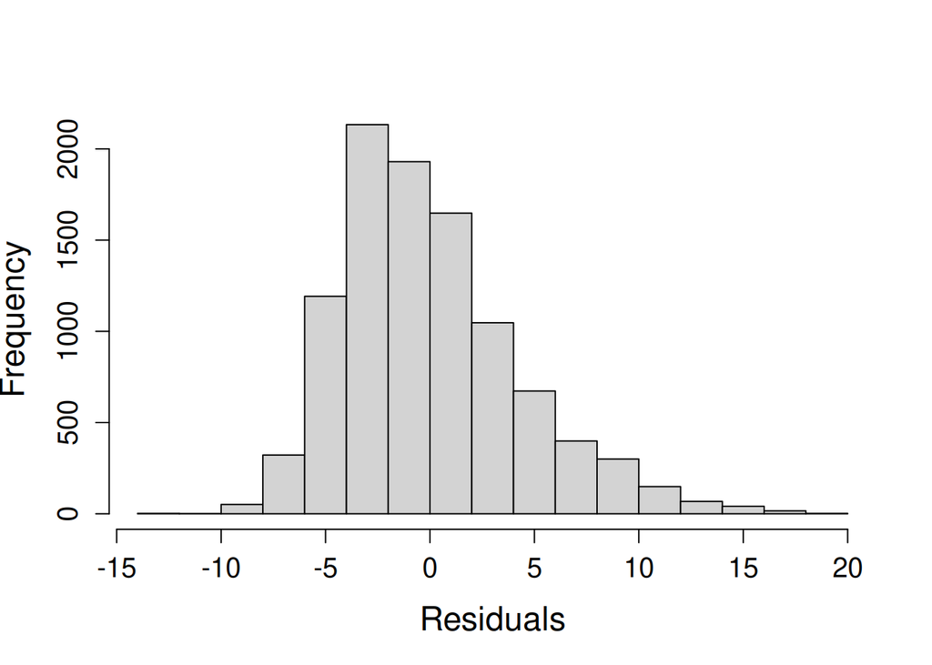

```r
## are residuals normal?
hist(lm4$residuals, xlab = "Residuals", cex.axis = 1.25, cex.lab = 1.5, main = "")
```

```r
## is the variability of the residuals is nearly constant?
z <- data.frame(
  fitted_values = predict(lm4),
  abs_residuals = abs(lm4$residuals)
)
lm5 <- lm(abs_residuals ~ fitted_values, z)
summary(lm5)
```

```
Call:
lm(formula = abs_residuals ~ fitted_values, data = z)

Residuals:
    Min      1Q  Median      3Q     Max
-4.6296 -1.9292 -0.4395  1.2485 15.7516

Coefficients:
              Estimate Std. Error t value Pr(>|t|)
(Intercept)    1.32541    0.13110   10.11   <2e-16 ***
fitted_values  0.16472    0.01034   15.93   <2e-16 ***
---
Signif. codes:  0 '***' 0.001 '**' 0.01 '*' 0.05 '.' 0.1 ' ' 1

Residual standard error: 2.632 on 9972 degrees of freedom
Multiple R-squared:  0.02482,   Adjusted R-squared:  0.02473
F-statistic: 253.9 on 1 and 9972 DF,  p-value: < 2.2e-16
```

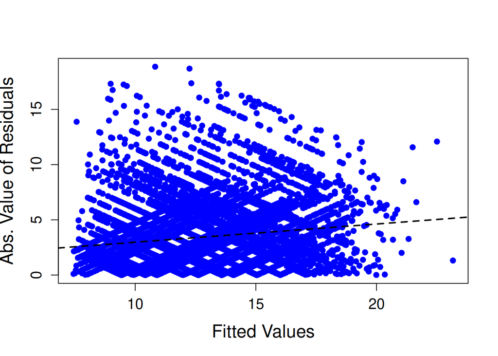

```r
## are the residuals independent?
plot(z$fitted_values, z$abs_residuals, col = "blue", pch = 19,
     xlab = "Fitted Values", ylab = "Abs. Value of Residuals",
     cex.axis = 1.25, cex.lab = 1.5)
abline(lm5, lwd = 2, lty = 2)
```

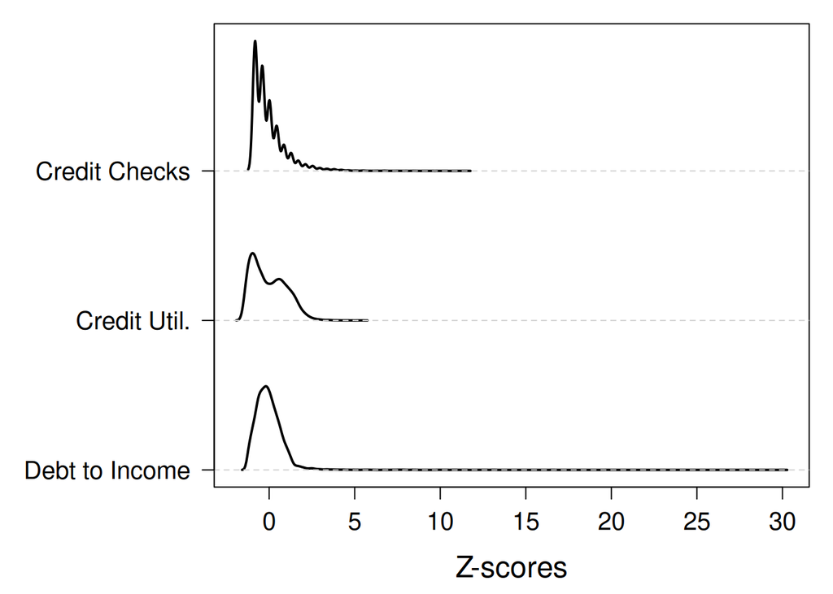

```r
### outliers
z <- data.frame(
  z1 = y1$debt_to_income,
  z2 = y1$credit_util,
  z3 = y1$credit_checks
)

for(i in 1:ncol(z)){
  z[,i] <- (z[,i] - mean(z[,i])) / sd(z[,i])
}

d1 <- density(z[,1])
d2 <- density(z[,2])
d3 <- density(z[,3])

jump <- max(c(d1$y, d2$y, d3$y))*1.15
z <- data.frame(
  x = c(d1$x, NA, d2$x, NA, d3$x),
  y = c(d1$y, NA, d2$y + jump, NA, d3$y + jump * 2)
)

par(mfrow = c(1, 1), mar = c(4.5, 9, 1, 1))
plot(z$x, z$y, type = "l", lwd = 2,
     ylab = "", yaxt = 'n',
     xlab = "Z-scores", cex.axis = 1.25, cex.lab = 1.5)
abline(h = c(0, jump, jump*2), lty = 2, col = "lightgrey")
axis(2, at = c(0, jump, jump*2),
     labels = c("Debt to Income", "Credit Util.", "Credit Checks"),
     cex.axis = 1.25, las = 1)
```

- The main concern for the initial model is that there is a notable nonlinear relationship between the debt-to-income variable
  - To resolve this issue, we’re going to consider a couple strategies for adjusting the relationship between the predictor variable and the outcome.
- Below are several options:
  - log transformation ($log(x)$),
  - square root transformation ($\sqrt{x}$),
  - truncation (cap the max value possible)
  - subsetting (dropping all observations beyond a max value)

[figure not shown]

```r
par(mfrow = c(2,2), mar = c(4.5, 4.5, 1, 1))

plot(log(y1$debt_to_income), y1$residuals,
     xlab = "log(Debt to Income)", ylab = "Residuals",
     cex.lab = 1.5, cex.axis = 1.25)

plot(sqrt(y1$debt_to_income), y1$residuals,
     xlab = "sqrt(Debt to Income)", ylab = "Residuals",
     cex.lab = 1.5, cex.axis = 1.25)

plot(ifelse(y1$debt_to_income > 50, 50, y1$debt_to_income), y1$residuals,
     xlab = "Debt to Income (Truncated)", ylab = "Residuals",
     cex.lab = 1.5, cex.axis = 1.25)

plot(y1$debt_to_income[y1$debt_to_income <= 50],
     y1$residuals[y1$debt_to_income <= 50],
     xlab = "Debt to Income (< 50)", ylab = "Residuals",
     cex.lab = 1.5, cex.axis = 1.25)
```

```r
## subset
y2 <- subset(y1, y1$debt_to_income < 50)

## run regression
lm4_subset <- lm(interest_rate ~ income_ver + debt_to_income + credit_util + bankruptcy + term + credit_checks, data = y2)

## summarize
summary(lm4_subset)
```

```
Call:
lm(formula = interest_rate ~ income_ver + debt_to_income + credit_util +
    bankruptcy + term + credit_checks, data = y2)

Residuals:
     Min       1Q   Median       3Q      Max
-12.1831  -3.0513  -0.7189   2.3429  19.0002

Coefficients:
                          Estimate Std. Error t value Pr(>|t|)
(Intercept)               1.397888   0.204143   6.848 7.96e-12 ***
income_verSource Verified 1.055430   0.099112  10.649  < 2e-16 ***
income_verVerified        2.530554   0.118464  21.361  < 2e-16 ***
debt_to_income            0.058999   0.004659  12.663  < 2e-16 ***
credit_util               4.584958   0.164090  27.942  < 2e-16 ***
bankruptcy                0.387483   0.132573   2.923  0.00348 **
term                      0.152700   0.003960  38.560  < 2e-16 ***
credit_checks             0.219747   0.018293  12.013  < 2e-16 ***
---
Signif. codes:  0 '***' 0.001 '**' 0.01 '*' 0.05 '.' 0.1 ' ' 1

Residual standard error: 4.276 on 9801 degrees of freedom
Multiple R-squared:  0.2691,    Adjusted R-squared:  0.2686
F-statistic: 515.5 on 7 and 9801 DF,  p-value: < 2.2e-16
```

### Example 3: Mario Kart

- We’ll examine **eBay auctions** for the video game *Mario Kart* on the **Nintendo Wii**.
  - The **outcome variable** is the **total auction price**, defined as the *winning bid plus shipping cost*.
  - Our goal is to understand how the total price varies with different **auction characteristics**, while **controlling for other factors**.
- Holding other characteristics constant:
  - Are **longer auctions** associated with **higher or lower prices**?
  - On average, how much more do buyers pay for **additional Wii wheels** (the plastic steering wheel attachments for Wii controllers)?

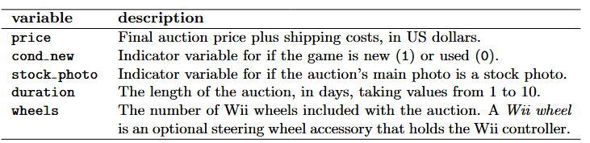

```r
## read in data
x <- read.csv("data/mariokart.csv")

## simplify
x <- data.frame(
  price = x$total_pr,
  cond_new = ifelse(x$cond == "new", 1, 0),
  stock_photo = ifelse(x$stock_photo == "yes", 1, 0),
  duration = x$duration,
  wheels = x$wheels
)

## peak at data
head(x)
```

```
  price cond_new stock_photo duration wheels
1 51.55        1           1        3      1
2 37.04        0           1        7      1
3 45.50        1           0        3      1
4 44.00        1           1        3      1
5 71.00        1           1        1      2
6 45.00        1           1        3      0
```

```r
## univariate regression
lm1 <- lm(price ~ cond_new, data = x)
summary(lm1)
```

```
Call:
lm(formula = price ~ cond_new, data = x)

Residuals:
    Min      1Q  Median      3Q     Max
-18.168  -7.771  -3.148   1.857 279.362

Coefficients:
            Estimate Std. Error t value Pr(>|t|)
(Intercept)   47.148      2.790  16.900   <2e-16 ***
cond_new       6.623      4.343   1.525     0.13
---
Signif. codes:  0 '***' 0.001 '**' 0.01 '*' 0.05 '.' 0.1 ' ' 1

Residual standard error: 25.57 on 141 degrees of freedom
Multiple R-squared:  0.01622,   Adjusted R-squared:  0.009244
F-statistic: 2.325 on 1 and 141 DF,  p-value: 0.1296
```

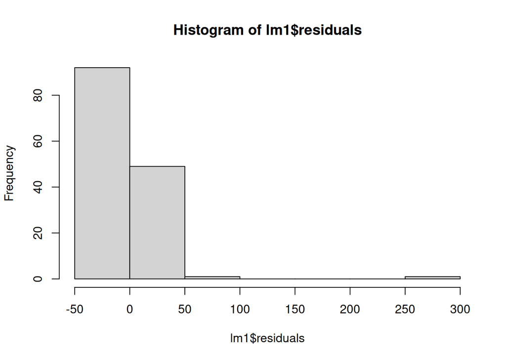

```r
hist(lm1$residuals)
```

```r
## remove outliers
z <- x$price
z <- (z - mean(z)) / sd(z)
x1 <- x[z <= 2.56,]

## univariate regression, removed outliers
lm2 <- lm(price ~ cond_new, data = x1)
summary(lm2)
```

```
Call:
lm(formula = price ~ cond_new, data = x1)

Residuals:
     Min       1Q   Median       3Q      Max
-13.8911  -5.8311   0.1289   4.1289  22.1489

Coefficients:
            Estimate Std. Error t value Pr(>|t|)
(Intercept)   42.871      0.814  52.668  < 2e-16 ***
cond_new      10.900      1.258   8.662 1.06e-14 ***
---
Signif. codes:  0 '***' 0.001 '**' 0.01 '*' 0.05 '.' 0.1 ' ' 1

Residual standard error: 7.371 on 139 degrees of freedom
Multiple R-squared:  0.3506,    Adjusted R-squared:  0.3459
F-statistic: 75.03 on 1 and 139 DF,  p-value: 1.056e-14
```

```r
hist(lm1$residuals)

## multivariate regression
lm3 <- lm(price ~ cond_new + stock_photo + duration + wheels, data = x1)
summary(lm3)
```

[output not shown]

```
Call:
lm(formula = price ~ cond_new + stock_photo + duration + wheels,
    data = x1)

Residuals:
     Min       1Q   Median       3Q      Max
-11.3788  -2.9854  -0.9654   2.6915  14.0346

Coefficients:
            Estimate Std. Error t value Pr(>|t|)
(Intercept) 36.21097    1.51401  23.917  < 2e-16 ***
cond_new     5.13056    1.05112   4.881 2.91e-06 ***
stock_photo  1.08031    1.05682   1.022    0.308
duration    -0.02681    0.19041  -0.141    0.888
wheels       7.28518    0.55469  13.134  < 2e-16 ***
---
Signif. codes:  0 '***' 0.001 '**' 0.01 '*' 0.05 '.' 0.1 ' ' 1

Residual standard error: 4.901 on 136 degrees of freedom
Multiple R-squared:  0.719, Adjusted R-squared:  0.7108
F-statistic: 87.01 on 4 and 136 DF,  p-value: < 2.2e-16
```

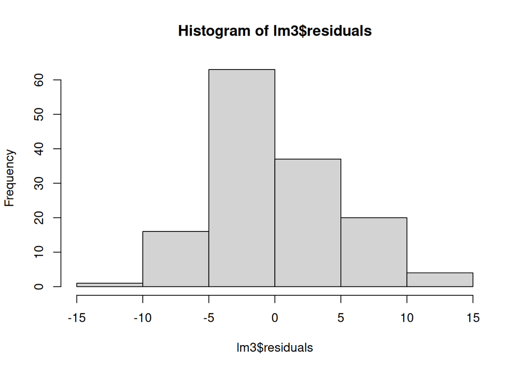

```r
hist(lm3$residuals)
```

```r
## model selection, drop duration
lm4 <- lm(price ~ cond_new + stock_photo + wheels, data = x1)

## slight improvement in model performance
summary(lm4)$adj.r.squared - summary(lm3)$adj.r.squared
```

```
[1] 0.002069379
```

```r
## summarize model 4
summary(lm4)
```

```
Call:
lm(formula = price ~ cond_new + stock_photo + wheels, data = x1)

Residuals:
    Min      1Q  Median      3Q     Max
-11.454  -2.959  -0.949   2.712  14.061

Coefficients:
            Estimate Std. Error t value Pr(>|t|)
(Intercept)  36.0483     0.9745  36.990  < 2e-16 ***
cond_new      5.1763     0.9961   5.196 7.21e-07 ***
stock_photo   1.1177     1.0192   1.097    0.275
wheels        7.2984     0.5448  13.397  < 2e-16 ***
---
Signif. codes:  0 '***' 0.001 '**' 0.01 '*' 0.05 '.' 0.1 ' ' 1

Residual standard error: 4.884 on 137 degrees of freedom
Multiple R-squared:  0.719, Adjusted R-squared:  0.7128
F-statistic: 116.8 on 3 and 137 DF,  p-value: < 2.2e-16
```

```r
lm5 <- lm(price ~ cond_new + wheels, data = x1)

## slight worsening in model performance
summary(lm5)$adj.r.squared - summary(lm4)$adj.r.squared
```

```
[1] -0.0004217509
```

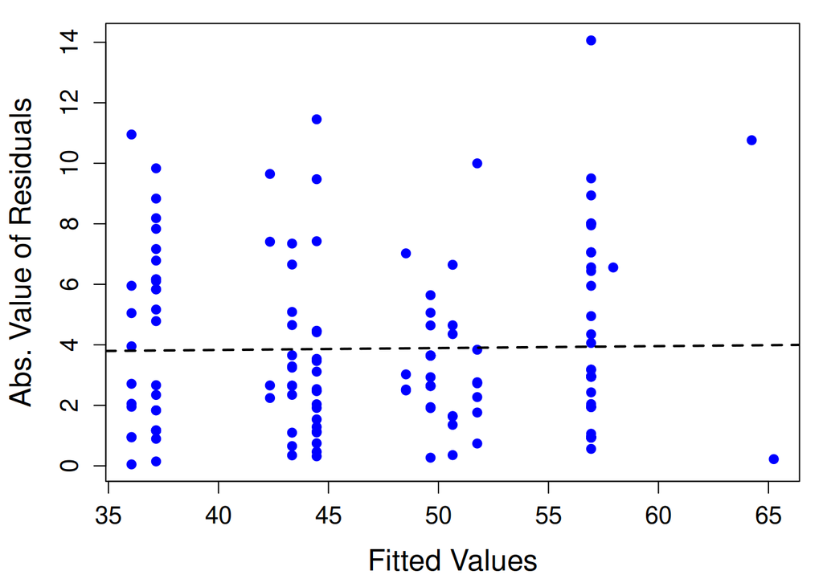

```r
### check out model residuals
par(mar = c(4.5, 4.5, 1, 1))
plot(predict(lm4), abs(lm4$residuals),
     ylab = "Abs. Value of Residuals",
     xlab = "Fitted Values",
     cex.lab = 1.5, cex.axis = 1.25,
     col = "blue", pch = 19)
abline(lm(abs(lm4$residuals) ~ predict(lm4)), lty = 2, lwd = 2)
```

## Logistic Regression

- In this section, we introduce **logistic regression** as a modeling tool for cases where the **response variable is categorical with two levels**, such as *Yes/No* or *Success/Failure*.
- Logistic regression is a type of **generalized linear model (GLM)** that is well-suited for response variables where **ordinary multiple regression** performs poorly.
  - In these settings, the residuals often **deviate sharply from the normal distribution**, violating key regression assumptions.
- **Logistic regression** is a GLM used when the outcome variable is **binary**.
  - The outcome $Y_i$ takes the value 1 with probability $p_i$ and 0 with probability $1 - p_i$.
  - Because each observation has a unique context (e.g., education, experience, etc.), the probability $p_i$ can vary across individuals.
- We will assess model quality using the **Akaike Information Criterion (AIC)** — a measure that balances **model fit** and **model simplicity**.
  - Conceptually, AIC plays a similar role here to **adjusted $R^2$** in multiple regression, helping us compare models and penalize unnecessary complexity.

$$\text{transformation}(p_i) = \beta_0 + \beta_1 x_1 + ... + \beta_k x_k$$

$$logit(p_i) = log_e \bigg( \dfrac{p_i}{1 - p_i} \bigg) = ln \bigg( \dfrac{p_i}{1 - p_i} \bigg)$$

$$ln \bigg( \dfrac{p_i}{1 - p_i} \bigg) = \beta_0 + \beta_1 x_1 + ... + \beta_k x_k$$

$$p_i = \dfrac{e^{\beta_0 + \beta_1 x_1 + ... + \beta_k x_k}}{1 + e^{\beta_0 + \beta_1 x_1 + ... + \beta_k x_k}}$$

```r
y <- data.frame(
  p = seq(0, 1, 0.01)
)
y$logit <- log(y$p / (1 - y$p))
head(y)
```

```
     p     logit
1 0.00      -Inf
2 0.01 -4.595120
3 0.02 -3.891820
4 0.03 -3.476099
5 0.04 -3.178054
6 0.05 -2.944439
```

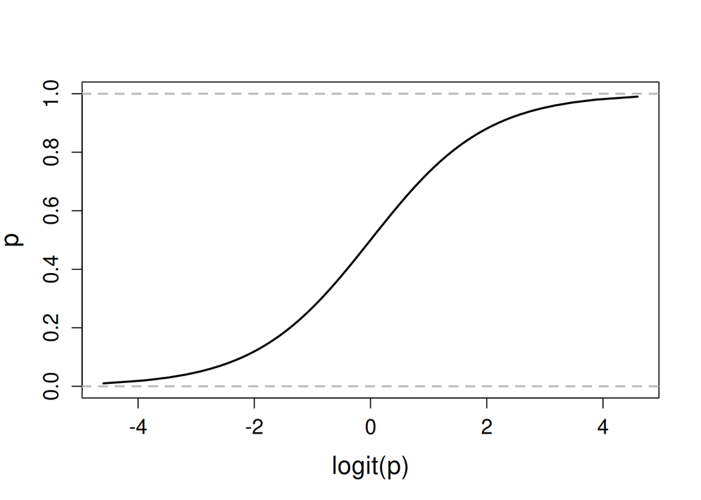

```r
plot(y$logit, y$p, type = "l", lwd = 2,
     xlab = "logit(p)", ylab = "p",
     cex.axis = 1.25, cex.lab = 1.5)
abline(h = c(0, 1), lty = 2, col = "grey", lwd = 2)
```

- The figure above is important for visualizing the key difference between logit and linear regression: the risk of nonsensical predictions outside the observed range of the data
- A linear regression with a binary outcome is called a **linear probability model** (LPM)
  - The upside of the LPM is interpretability: “a one-unit increase in $x$ changes the predicted probability that $y = 1$ by $\beta_1$, holding all else constant”
  - The downside is that predicted probabilities can easily fall below $0$ or above $1$ – values that have no meaning as probabilities
  - The logit model is bounded between $0$ and $1$ by construction, since the logistic function maps any real number into that interval